# PLS2 — Relación bacterias-metabolitos — Leonard et al. (2021)

2026-06-29

Este script relaciona las bacterias (species) y los metabolitos identificados como `EC_specific` en el análisis de LMM, mediante PLS2.

1. Selección de bacterias y metabolitos significativos en el LMM.
2. PLS2 (X = bacterias, Y = metabolitos) con al menos 10 componentes.
3. Selección del número definitivo de componentes.
4. Gráficos de scores (coloreados por grupo/tiempo) y de loadings/weights, para identificar bacterias y metabolitos que actúan de forma coordinada.
5. Significación de las relaciones bacteria-metabolito mediante los coeficientes de regresión del PLS2, comparando jackknife, permutación y VIP.
6. Repetición del análisis por separado para casos y controles, para comprobar si la relación bacteria-metabolito cambia entre condiciones.

# 1. Carga de datos y selección de variables EC-specific

Se cargan las matrices transformadas (CLR para species, log para metabolitos) y las tablas de resultados del LMM. De estas últimas se extraen los nombres de las variables marcadas como `EC_specific`, que serán las variables de entrada (X) y salida (Y) del PLS.

```r
library(tidyverse)
library(PLSandO)
library(gridExtra)
```

```r
library(igraph)
library(tidygraph)
library(ggraph)
library(here)
processed_dir <- here("data", "processed", "leonard_2021")

species_clr_data     <- readRDS(file.path(processed_dir, "species_clr_data.rds"))
metabolites_log_data <- readRDS(file.path(processed_dir, "metabolites_log_data.rds"))

species_lmm_results     <- readRDS(file.path(processed_dir, "species_lmm_results.rds"))
metabolites_lmm_results <- readRDS(file.path(processed_dir, "metabolites_lmm_results.rds"))

variables_species     <- species_lmm_results     %>% filter(EC_specific) %>% pull(variable)
variables_metabolites <- metabolites_lmm_results %>% filter(EC_specific) %>% pull(variable)

cat("Species EC-specific:    ", length(variables_species), "\n")
```

```
## Species EC-specific:     29
```

```r
cat("Metabolitos EC-specific: ", length(variables_metabolites), "\n")
```

```
## Metabolitos EC-specific:  21
```

# 2. Alineación de muestras entre species y metabolitos

Las matrices de species y metabolitos no comparten necesariamente las mismas muestras exactas: al tratarse de dos ómicas distintas, es posible que en algún punto de tiempo se recogiera muestra para una técnica pero no para la otra. Se construye una clave única por muestra (`sujeto_tiempo_relativo`) y se conservan solo las muestras presentes en ambas matrices (`intersect`), ordenadas de forma idéntica para garantizar que cada fila de X se corresponda con la misma fila de Y.

```r
species_key     <- species_clr_data     %>% mutate(sample_key = paste(PaperID, relative_month, sep = "_"))
metabolites_key <- metabolites_log_data %>% mutate(sample_key = paste(PaperID, relative_month, sep = "_"))

common_keys <- intersect(species_key$sample_key, metabolites_key$sample_key)

cat("Muestras species:     ", nrow(species_key), "\n")
```

```
## Muestras species:      118
```

```r
cat("Muestras metabolitos: ", nrow(metabolites_key), "\n")
```

```
## Muestras metabolitos:  118
```

```r
cat("Muestras comunes:     ", length(common_keys), "\n")
```

```
## Muestras comunes:      117
```

```r
species_aligned     <- species_key     %>% filter(sample_key %in% common_keys) %>% arrange(sample_key)
metabolites_aligned <- metabolites_key %>% filter(sample_key %in% common_keys) %>% arrange(sample_key)

identical(species_aligned$sample_key, metabolites_aligned$sample_key)
```

```
## [1] TRUE
```

Se comprueban las muestras que no casan entre ambas matrices, para verificar que la pérdida de muestras (de 118 a 117) se debe a una diferencia real en el diseño de recogida (`Control_1` tiene muestras de metaboloma y de microbioma en puntos de tiempo distintos en el extremo más temprano de la ventana) y no a un error de construcción de la clave.

```r
setdiff(species_key$sample_key, metabolites_key$sample_key)
```

```
## [1] "Control_1_-15"
```

```r
setdiff(metabolites_key$sample_key, species_key$sample_key)
```

```
## [1] "Control_1_-12"
```

# 3. Construcción de las matrices X (species) e Y (metabolitos)

```r
X <- species_aligned     %>% select(all_of(variables_species))     %>% as.data.frame()
Y <- metabolites_aligned %>% select(all_of(variables_metabolites)) %>% as.data.frame()

rownames(X) <- species_aligned$sample_key
rownames(Y) <- metabolites_aligned$sample_key

cat("Filas X:", nrow(X), "| Columnas X:", ncol(X), "\n")
```

```
## Filas X: 117 | Columnas X: 29
```

```r
cat("Filas Y:", nrow(Y), "| Columnas Y:", ncol(Y), "\n")
```

```
## Filas Y: 117 | Columnas Y: 21
```

# 4. PLS2 — modelo conjunto (todas las muestras)

## 4.1 Selección del número de componentes

Se ajusta primero un modelo exploratorio con `ncomp = 10`, y se examina el gráfico R²/Q² por componente (equivalente, para PLS, al scree plot del PCA) para decidir el número definitivo de componentes.

```r
set.seed(123)

modelo_pls2 <- pls(
  x        = X,
  y        = Y,
  ncomp    = 10,
  cvFolds  = 5,
  rep      = 10,
  perm     = 100,
  scaling  = "standard",
  scalingY = "standard",
  algo     = "nipals",
  train    = 1,
  parallel = FALSE
)
```

[output not shown]

[output not shown]

```r
modelo_pls2$summary
```

```
##    comp        R2X    cumR2X         R2Y     cumR2Y          Q2       cumQ2
## 1     1 0.15017364 0.1501736 0.061403877 0.06140388 -0.02958693 -0.02958693
## 2     2 0.10865867 0.2588323 0.045062896 0.10646677 -0.08780998 -0.11739691
## 3     3 0.07139241 0.3302247 0.027746010 0.13421278 -0.05738258 -0.17477949
## 4     4 0.08744181 0.4176665 0.011760699 0.14597348 -0.02934863 -0.20412812
## 5     5 0.05660935 0.4742759 0.009420447 0.15539393 -0.01162201 -0.21575013
## 6     6 0.04590094 0.5201768 0.009187281 0.16458121 -0.02443325 -0.24018337
## 7     7 0.04228925 0.5624661 0.008592879 0.17317409 -0.02324943 -0.26343280
## 8     8 0.05539916 0.6178652 0.004851252 0.17802534 -0.03307819 -0.29651099
## 9     9 0.03808780 0.6559530 0.006902415 0.18492776 -0.03268358 -0.32919458
## 10   10 0.03053026 0.6864833 0.007196938 0.19212470 -0.02734839 -0.35654296
##        RMSE
## 1  1.010307
## 2  1.052422
## 3  1.079112
## 4  1.092477
## 5  1.097717
## 6  1.108666
## 7  1.119017
## 8  1.133533
## 9  1.147774
## 10 1.159529
```

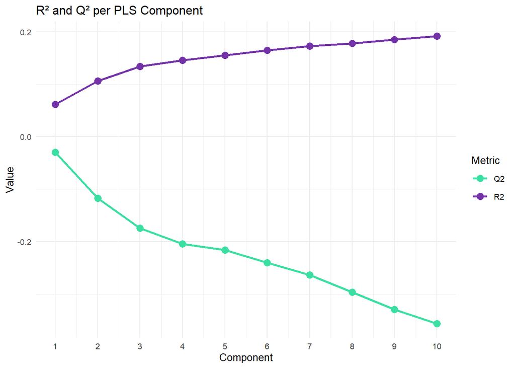

```r
plsPlot(modelo_pls2, type = "R2vsQ2")
```

El codo se sitúa en la componente 4: hasta ahí cada componente aporta más de un 1% de R²Y individual, y a partir de la 5 la caída pasa a ser una meseta plana con ruido (incluso sube en algún punto posterior). Se fija `ncomp = 4` y se reajusta el modelo.

```r
set.seed(123)

modelo_pls2 <- pls(
  x        = X,
  y        = Y,
  ncomp    = 4,
  cvFolds  = 5,
  rep      = 10,
  perm     = 100,
  scaling  = "standard",
  scalingY = "standard",
  algo     = "nipals",
  train    = 1,
  parallel = FALSE
)
```

[output not shown]

[output not shown]

```r
modelo_pls2$summary
```

```
##   comp        R2X    cumR2X        R2Y     cumR2Y          Q2       cumQ2
## 1    1 0.15017364 0.1501736 0.06140388 0.06140388 -0.02958693 -0.02958693
## 2    2 0.10865867 0.2588323 0.04506290 0.10646677 -0.08780998 -0.11739691
## 3    3 0.07139241 0.3302247 0.02774601 0.13421278 -0.05738258 -0.17477949
## 4    4 0.08744181 0.4176665 0.01176070 0.14597348 -0.02934863 -0.20412812
##       RMSE
## 1 1.010307
## 2 1.052422
## 3 1.079112
## 4 1.092477
```

## 4.2 Gráficos de scores

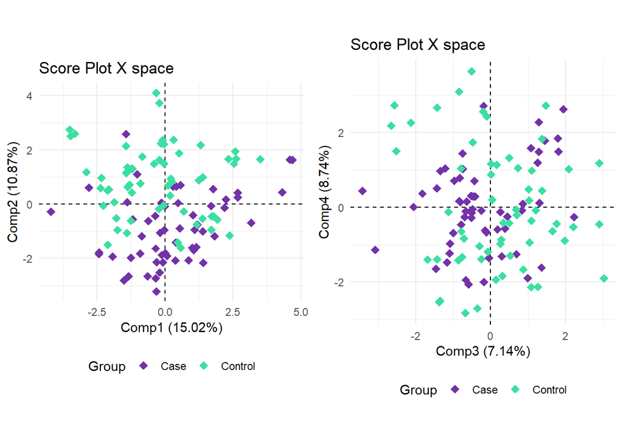

```r
covar_group <- data.frame(Group = species_aligned$group)
covar_time  <- factor(species_aligned$relative_month,
                      levels = c(-18, -15, -12, -9, -6, -3, 0))

p1_group <- plsPlot(modelo_pls2, type = "scoresX", comp = 1:2,
                     colBy = covar_group, labels = FALSE, ellipses = FALSE)


p11_group <- plsPlot(modelo_pls2, type = "scoresX", comp = 3:4,
                     colBy = covar_group, labels = FALSE, ellipses = FALSE)


grid.arrange(p1_group, p11_group, ncol = 2)
```

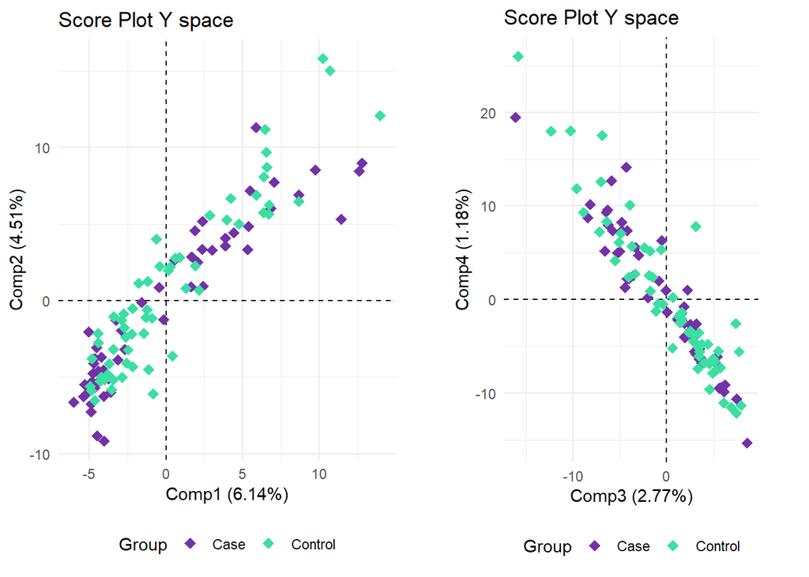

```r
p2_group <- plsPlot(modelo_pls2, type = "scoresY", comp = 1:2,
                     colBy = covar_group, labels = FALSE, ellipses = FALSE)


p21_group <- plsPlot(modelo_pls2, type = "scoresY", comp = 3:4,
                     colBy = covar_group, labels = FALSE, ellipses = FALSE)


grid.arrange(p2_group, p21_group, ncol = 2)
```

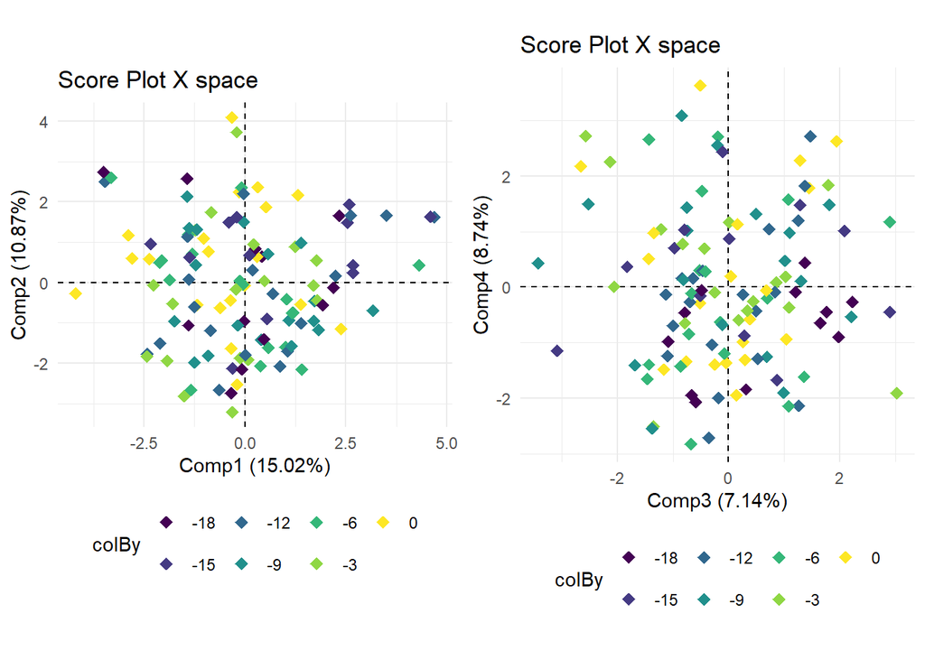

```r
p1_time <- plsPlot(modelo_pls2, type = "scoresX", comp = 1:2,
                    colBy = data.frame(relative_month = covar_time),
                    labels = FALSE, ellipses = FALSE) +
  scale_color_viridis_d(option = "viridis") +
  guides(fill = "none", shape = "none")
p11_time <- plsPlot(modelo_pls2, type = "scoresX", comp = 3:4,
                    colBy = data.frame(relative_month = covar_time),
                    labels = FALSE, ellipses = FALSE) +
  scale_color_viridis_d(option = "viridis") +
  guides(fill = "none", shape = "none")
grid.arrange(p1_time, p11_time, ncol = 2)
```

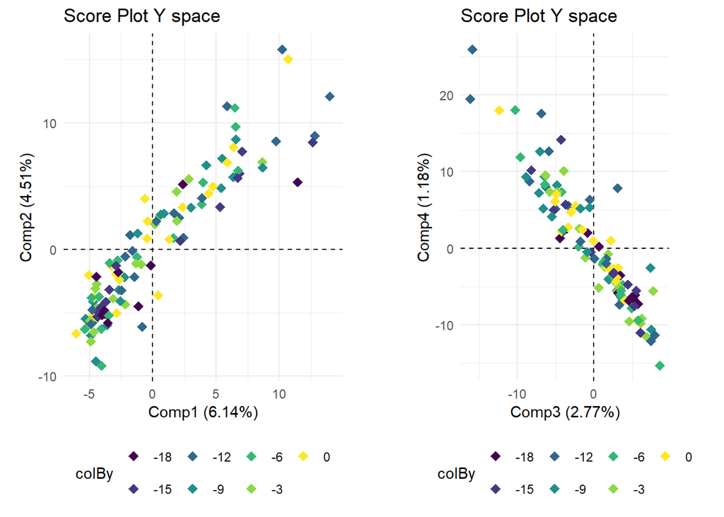

```r
p2_time <- plsPlot(modelo_pls2, type = "scoresY", comp = 1:2,
                    colBy = data.frame(relative_month = covar_time),
                    labels = FALSE, ellipses = FALSE) +
  scale_color_viridis_d(option = "viridis") +
  guides(fill = "none", shape = "none")
p21_time <- plsPlot(modelo_pls2, type = "scoresY", comp = 3:4,
                    colBy = data.frame(relative_month = covar_time),
                    labels = FALSE, ellipses = FALSE) +
  scale_color_viridis_d(option = "viridis") +
  guides(fill = "none", shape = "none")
grid.arrange(p2_time, p21_time, ncol = 2)
```

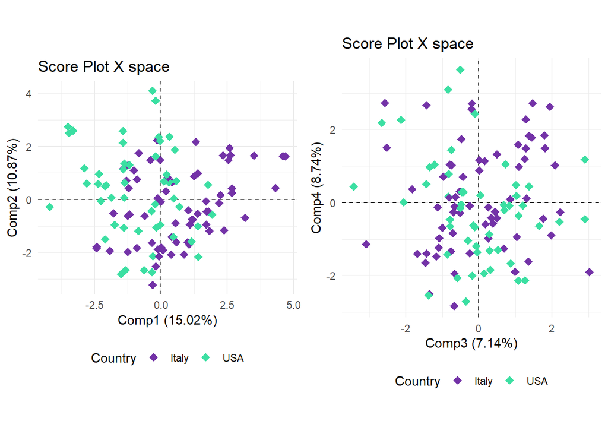

```r
covar_country <- data.frame(Country = species_aligned$Country)
p1_country <- plsPlot(modelo_pls2, type = "scoresX", comp = 1:2,
                     colBy = covar_country, labels = FALSE, ellipses = FALSE)


p11_country <- plsPlot(modelo_pls2, type = "scoresX", comp = 3:4,
                     colBy = covar_country, labels = FALSE, ellipses = FALSE)


grid.arrange(p1_country, p11_country, ncol = 2)
```

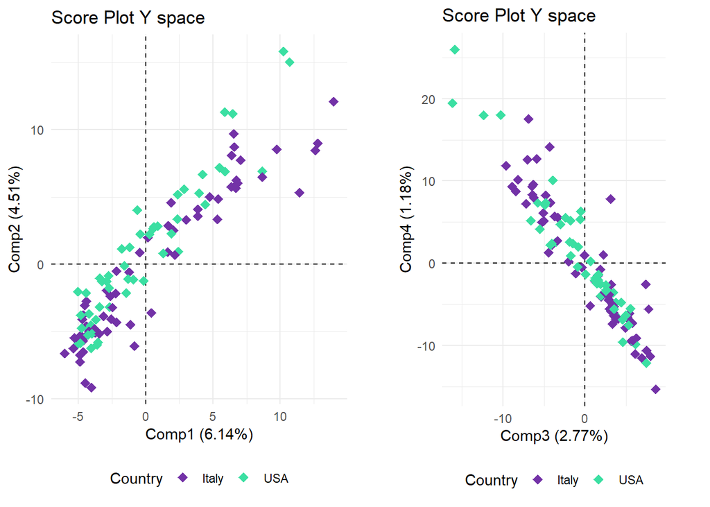

```r
p2_country <- plsPlot(modelo_pls2, type = "scoresY", comp = 1:2,
                     colBy = covar_country, labels = FALSE, ellipses = FALSE)


p21_country <- plsPlot(modelo_pls2, type = "scoresY", comp = 3:4,
                     colBy = covar_country, labels = FALSE, ellipses = FALSE)


grid.arrange(p2_country, p21_country, ncol = 2)
```

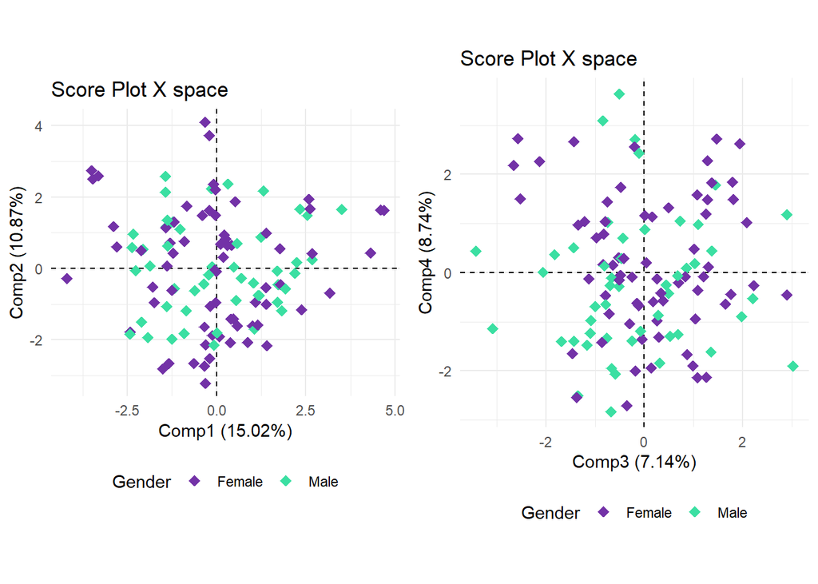

```r
covar_gender <- data.frame(Gender = species_aligned$Gender)
p1_gender <- plsPlot(modelo_pls2, type = "scoresX", comp = 1:2,
                     colBy = covar_gender, labels = FALSE, ellipses = FALSE)


p11_gender <- plsPlot(modelo_pls2, type = "scoresX", comp = 3:4,
                     colBy = covar_gender, labels = FALSE, ellipses = FALSE)


grid.arrange(p1_gender, p11_gender, ncol = 2)
```

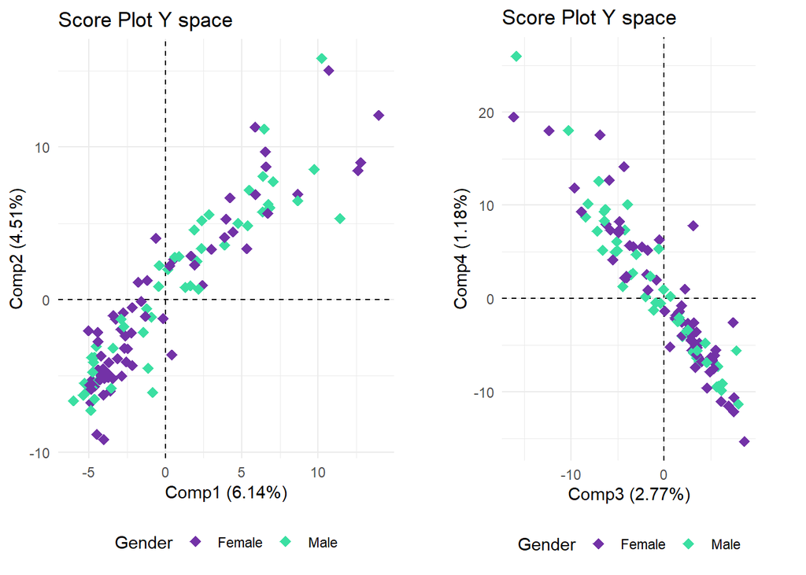

```r
p2_gender <- plsPlot(modelo_pls2, type = "scoresY", comp = 1:2,
                     colBy = covar_gender, labels = FALSE, ellipses = FALSE)


p21_gender <- plsPlot(modelo_pls2, type = "scoresY", comp = 3:4,
                     colBy = covar_gender, labels = FALSE, ellipses = FALSE)


grid.arrange(p2_gender, p21_gender, ncol = 2)
```

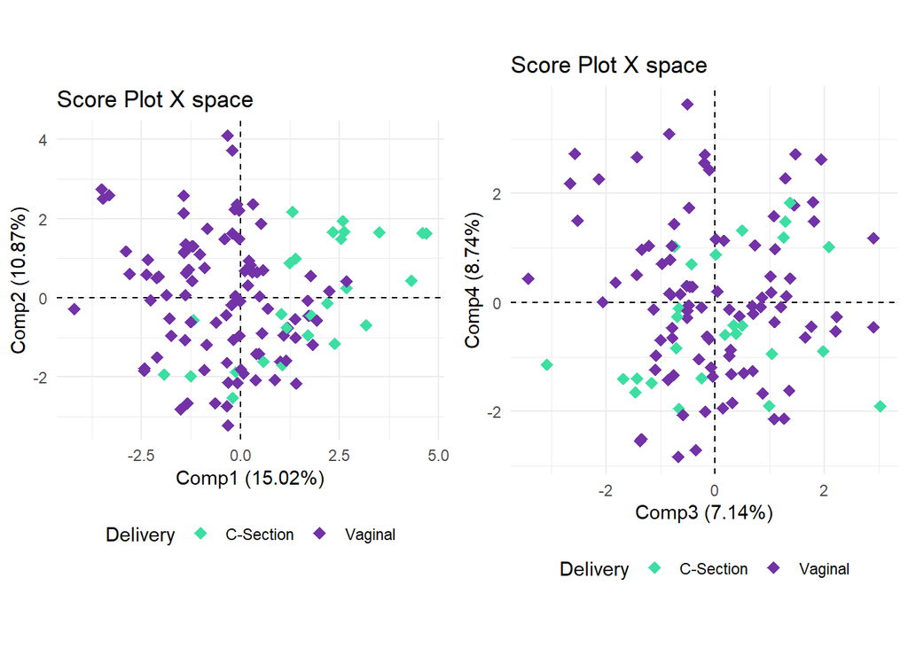

```r
covar_deliv <- data.frame(Delivery = species_aligned$Delivery_Mode)
p1_deliv <- plsPlot(modelo_pls2, type = "scoresX", comp = 1:2,
                     colBy = covar_deliv, labels = FALSE, ellipses = FALSE)


p11_deliv <- plsPlot(modelo_pls2, type = "scoresX", comp = 3:4,
                     colBy = covar_deliv, labels = FALSE, ellipses = FALSE)


grid.arrange(p1_deliv, p11_deliv, ncol = 2)
```

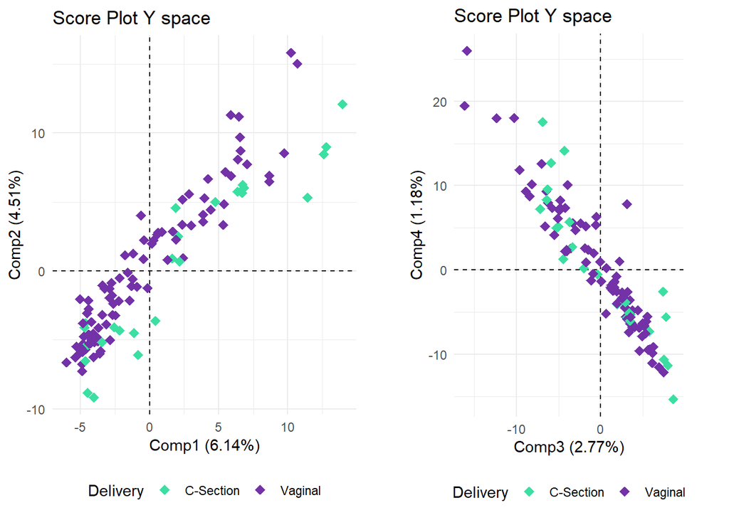

```r
p2_deliv <- plsPlot(modelo_pls2, type = "scoresY", comp = 1:2,
                     colBy = covar_deliv, labels = FALSE, ellipses = FALSE)


p21_deliv <- plsPlot(modelo_pls2, type = "scoresY", comp = 3:4,
                     colBy = covar_deliv, labels = FALSE, ellipses = FALSE)


grid.arrange(p2_deliv, p21_deliv, ncol = 2)
```

## 4.3 Gráficos de loadings

Sirven para identificar bacterias y metabolitos que se comportan de forma coordinada (próximos entre sí en el espacio de componentes).

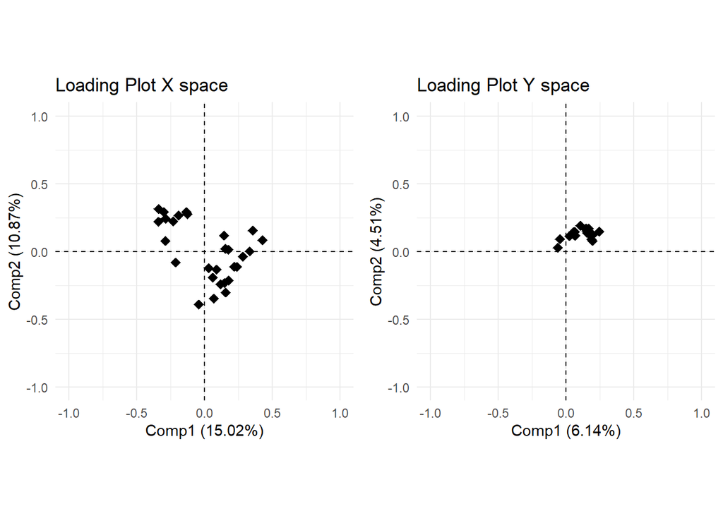

```r
p_loadX <- plsPlot(modelo_pls2, type = "loadingsX", comp = 1:2,
                    shape = "point", labels = FALSE, repel = TRUE)
p_loadY <- plsPlot(modelo_pls2, type = "loadingsY", comp = 1:2,
                    shape = "point", labels = FALSE, repel = TRUE)

grid.arrange(p_loadX, p_loadY, ncol = 2)
```

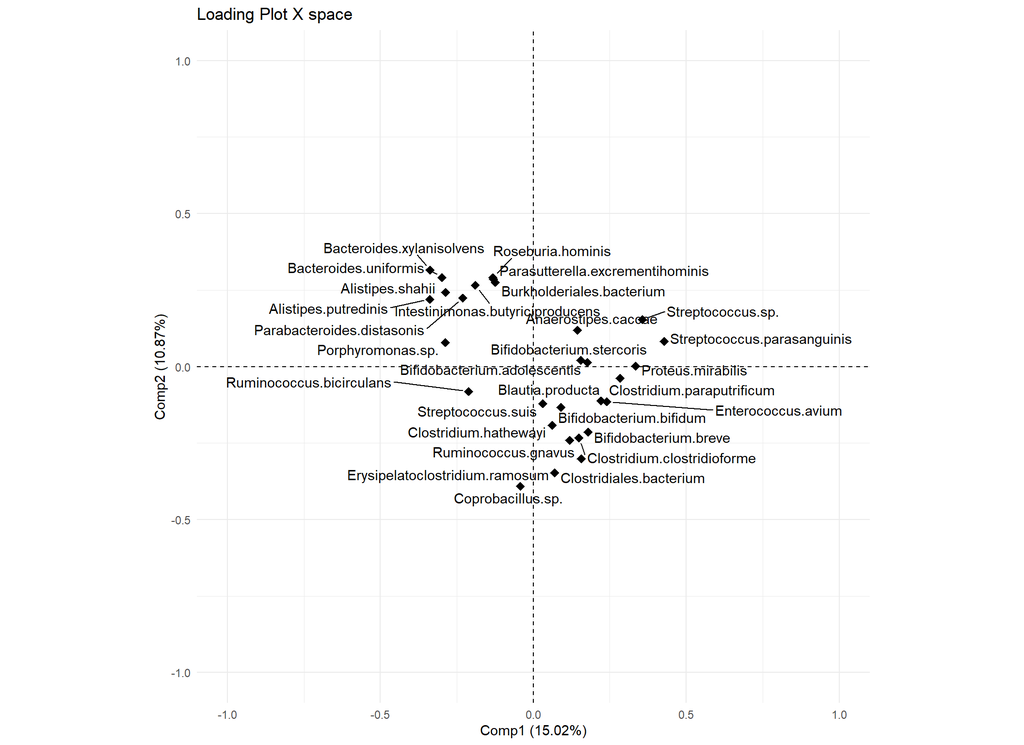

```r
plsPlot(modelo_pls2, type = "loadingsX", comp = 1:2,
        shape = "point", labels = TRUE, repel = TRUE)
```

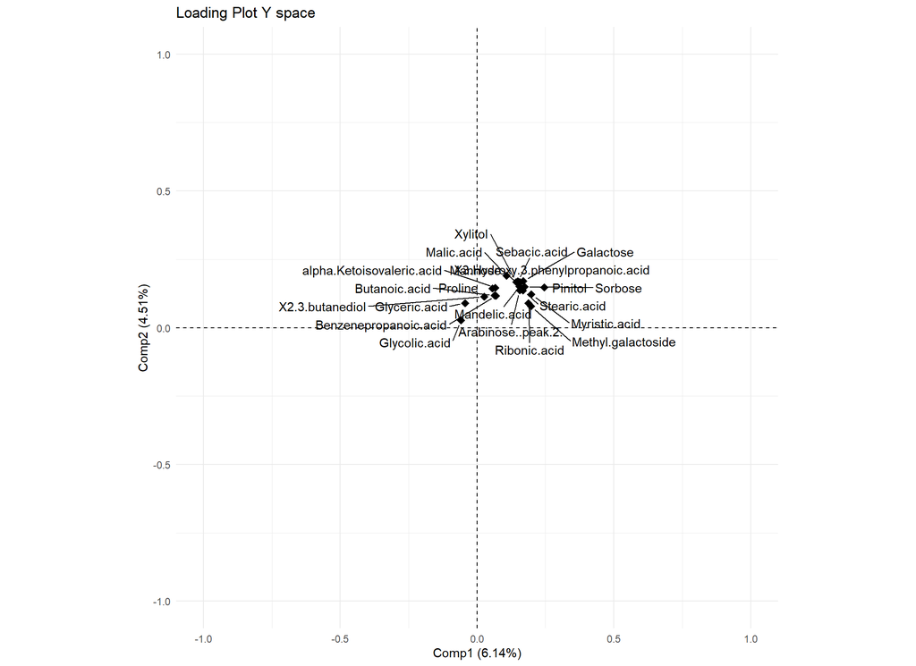

```r
plsPlot(modelo_pls2, type = "loadingsY", comp = 1:2,
        shape = "point", labels = TRUE, repel = TRUE)
```

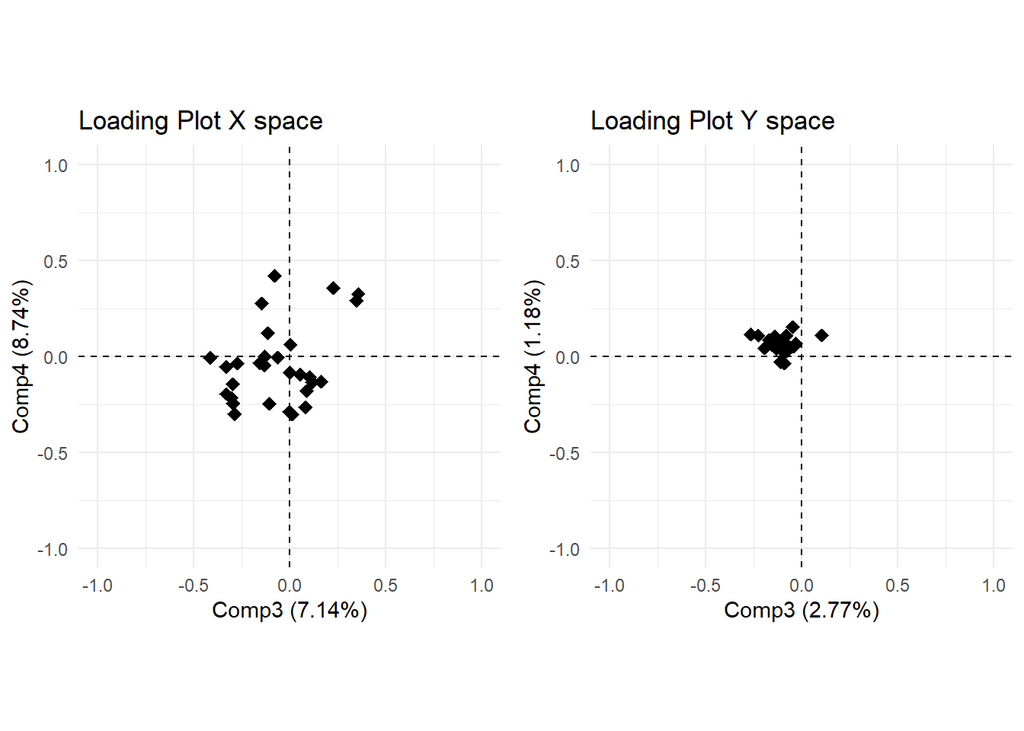

```r
p_loadX1 <- plsPlot(modelo_pls2, type = "loadingsX", comp = 3:4,
                    shape = "point", labels = FALSE, repel = TRUE)
p_loadY1 <- plsPlot(modelo_pls2, type = "loadingsY", comp = 3:4,
                    shape = "point", labels = FALSE, repel = TRUE)

grid.arrange(p_loadX1, p_loadY1, ncol = 2)
```

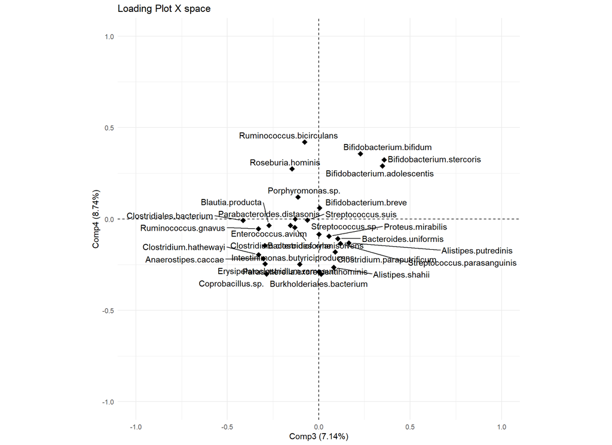

```r
plsPlot(modelo_pls2, type = "loadingsX", comp = 3:4,
        shape = "point", labels = TRUE, repel = TRUE)
```

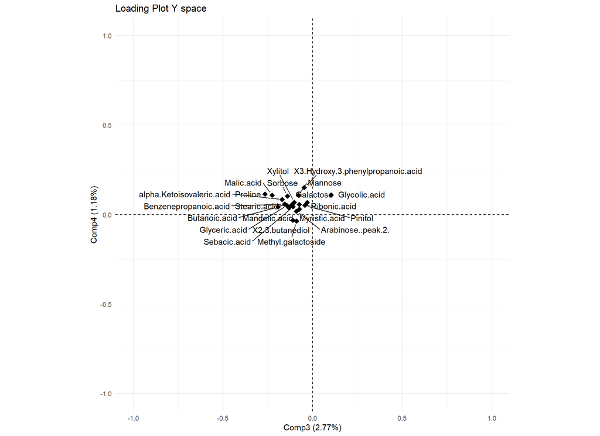

```r
plsPlot(modelo_pls2, type = "loadingsY", comp = 3:4,
        shape = "point", labels = TRUE, repel = TRUE)
```

Las bacterias se organizan en varias bandas a lo largo de Comp2, sugiriendo subgrupos con perfiles distintos. Los metabolitos, en cambio, quedan todos muy próximos entre sí en un mismo cuadrante — Comp1 y Comp2 están muy correlacionados en el espacio Y, sin subestructuras internas claras.

## 4.4 Gráfico de weights

Combina X e Y en el mismo espacio; es el que mejor refleja qué bacterias y metabolitos concretos se mueven juntos.

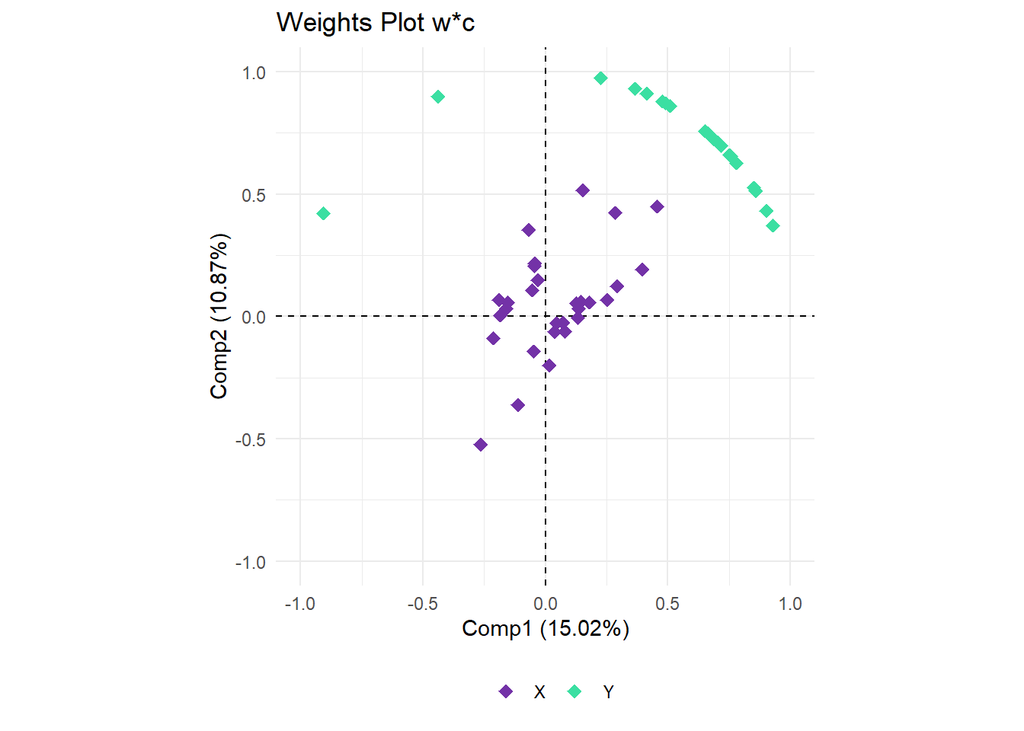

```r
plsPlot(modelo_pls2, type = "weights", comp = 1:2,
        shape = "point", labels = FALSE, repel = TRUE)
```

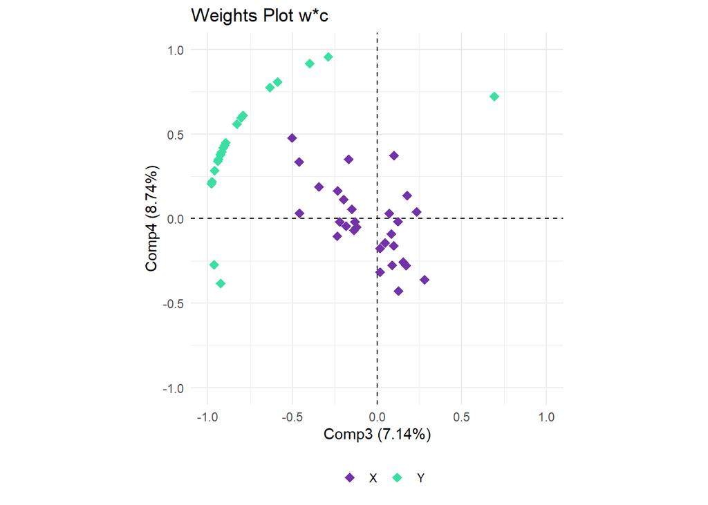

```r
plsPlot(modelo_pls2, type = "weights", comp = 3:4,
        shape = "point", labels = FALSE, repel = TRUE)
```

Versión con etiquetas:

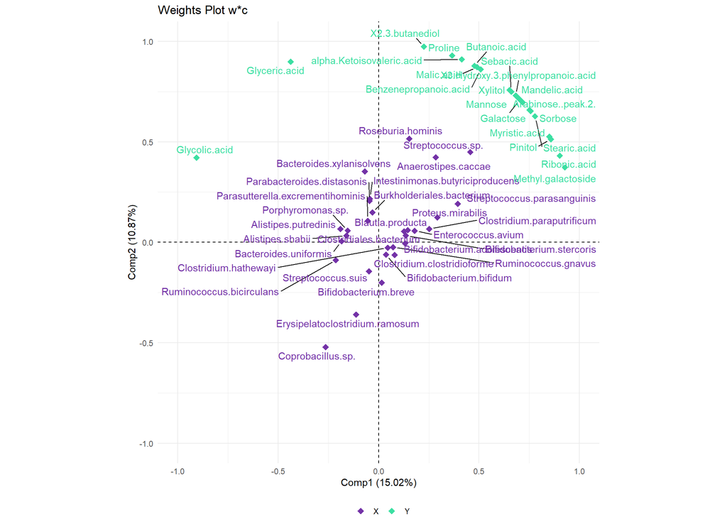

```r
plsPlot(modelo_pls2, type = "weights", comp = 1:2,
        labels = TRUE, repel = TRUE, shape= 'point')
```

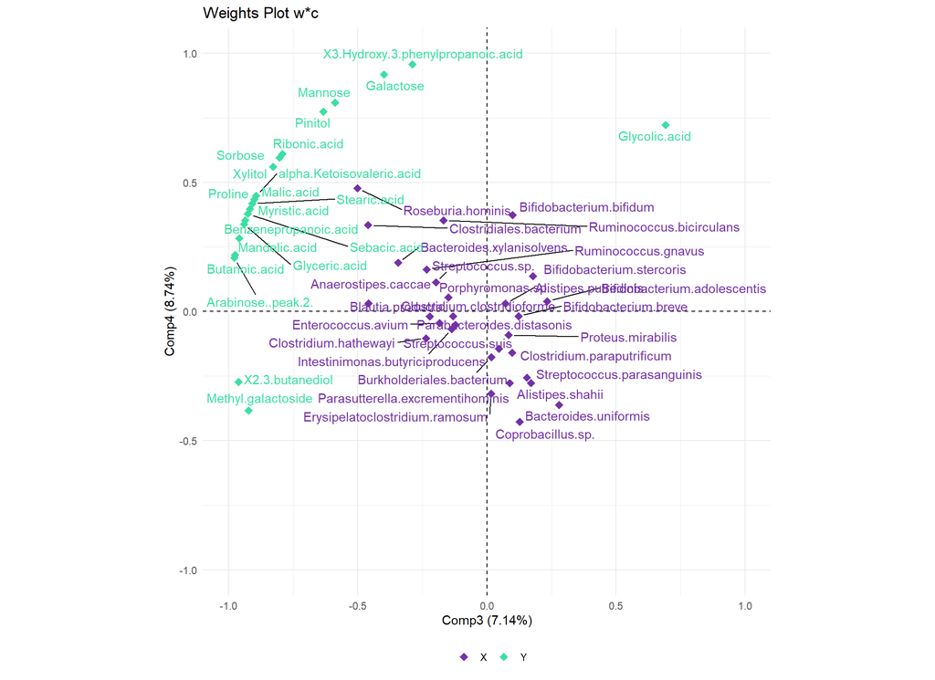

```r
plsPlot(modelo_pls2, type = "weights", comp = 3:4,
        labels = TRUE, repel = TRUE, shape= 'point')
```

## 4.5 Significación de las relaciones bacteria-metabolito

Se usan los coeficientes de regresión del PLS2 (`plsVarSel()`), comparando tres criterios: jackknife, permutación y VIP. Con `Y` de más de una columna, jackknife y permutación devuelven una lista con una tabla por metabolito (bacterias significativas para ese metabolito en concreto); VIP da una única puntuación de importancia global por bacteria, no específica de metabolito.

```r
set.seed(123)

jack_result <- plsVarSel(modelo_pls2, type = "Jack", rep = 100, threshold = 0.05)
```

```r
perm_result <- plsVarSel(modelo_pls2, type = "Perm", rep = 100, threshold = 0.05)
```

```r
vip_result  <- plsVarSel(modelo_pls2, type = "VIP")
```

```r
cat("Metabolitos con alguna bacteria significativa (Jack):", sum(sapply(jack_result, nrow) > 0), "\n")
```

```
## Metabolitos con alguna bacteria significativa (Jack): 0
```

```r
cat("Metabolitos con alguna bacteria significativa (Perm):", sum(sapply(perm_result, nrow) > 0), "\n")
```

```
## Metabolitos con alguna bacteria significativa (Perm): 9
```

```r
cat("Relaciones totales (Jack):", sum(sapply(jack_result, nrow)), "\n")
```

```
## Relaciones totales (Jack): 0
```

```r
cat("Relaciones totales (Perm):", sum(sapply(perm_result, nrow)), "\n")
```

```
## Relaciones totales (Perm): 18
```

```r
cat("Bacterias con VIP > 1:", nrow(vip_result), "\n")
```

```
## Bacterias con VIP > 1: 10
```

**Nota importante**: el jackknife no detecta ninguna relación significativa (0 en las 21 tablas), muy probablemente por la multicolinealidad entre bacterias (varias se mueven en bandas coordinadas, como se vio en los loadings), que infla los errores estándar del jackknife. La permutación sí encuentra señal, y coincide con el VIP en la totalidad de los casos (ver más abajo) — se toma esta combinación (Perm + VIP) como criterio de selección final, dejando constancia de que el jackknife no la respalda.

```r
bacterias_perm <- perm_result %>%
  discard(~ nrow(.x) == 0) %>%
  map(rownames) %>%
  unlist() %>%
  unique()

intersect(rownames(vip_result), bacterias_perm)
```

```
## [1] "Streptococcus.sp."              "Coprobacillus.sp."
## [3] "Roseburia.hominis"              "Anaerostipes.caccae"
## [5] "Erysipelatoclostridium.ramosum"
```

```r
perm_no_vacios <- perm_result[sapply(perm_result, nrow) > 0]

tabla_relaciones <- perm_no_vacios %>%
  imap_dfr(~ tibble(
    metabolito = .y,
    bacteria   = rownames(.x),
    p_perm     = .x$pValPerm
  )) %>%
  mutate(en_VIP = bacteria %in% rownames(vip_result)) %>%
  mutate(coeficiente = modelo_pls2$coefficients[cbind(bacteria, metabolito)]) %>%
  arrange(metabolito, p_perm)

tabla_relaciones
```

```
## # A tibble: 18 × 5
##    metabolito                        bacteria          p_perm en_VIP coeficiente
##    <chr>                             <chr>              <dbl> <lgl>        <dbl>
##  1 Galactose                         Coprobacillus.sp.   0.03 TRUE        -0.166
##  2 Malic.acid                        Roseburia.hominis   0    TRUE         0.280
##  3 Malic.acid                        Coprobacillus.sp.   0.01 TRUE        -0.203
##  4 Malic.acid                        Anaerostipes.cac…   0.04 TRUE         0.218
##  5 Malic.acid                        Streptococcus.sp.   0.04 TRUE         0.192
##  6 Mannose                           Coprobacillus.sp.   0.04 TRUE        -0.180
##  7 Methyl.galactoside                Streptococcus.sp.   0.04 TRUE         0.139
##  8 Pinitol                           Coprobacillus.sp.   0.02 TRUE        -0.169
##  9 Pinitol                           Streptococcus.sp.   0.03 TRUE         0.192
## 10 Proline                           Roseburia.hominis   0    TRUE         0.270
## 11 Proline                           Coprobacillus.sp.   0.04 TRUE        -0.172
## 12 Sorbose                           Roseburia.hominis   0.02 TRUE         0.223
## 13 Sorbose                           Coprobacillus.sp.   0.04 TRUE        -0.186
## 14 X3.Hydroxy.3.phenylpropanoic.acid Roseburia.hominis   0    TRUE         0.205
## 15 X3.Hydroxy.3.phenylpropanoic.acid Coprobacillus.sp.   0.01 TRUE        -0.199
## 16 X3.Hydroxy.3.phenylpropanoic.acid Streptococcus.sp.   0.02 TRUE         0.172
## 17 X3.Hydroxy.3.phenylpropanoic.acid Erysipelatoclost…   0.04 TRUE        -0.127
## 18 Xylitol                           Coprobacillus.sp.   0.04 TRUE        -0.167
```

18 relaciones entre 5 bacterias y 9 metabolitos, todas respaldadas también por el VIP.

```r
write_csv(tabla_relaciones, file.path(processed_dir, "relaciones_bacteria_metabolito_perm.csv"))
```

# 5. PLS2 separado por grupo (Case vs. Control)

Se repite el análisis completo por separado para casos y controles, para comprobar si la relación bacteria-metabolito cambia entre condiciones — algo esperable, ya que las variables de entrada se seleccionaron precisamente por su interacción con el grupo en el LMM. Se mantiene la misma selección de variables (29 species, 21 metabolitos); lo único que cambia es el subconjunto de muestras sobre el que se ajusta cada modelo.

## 5.1 División de las muestras por grupo

```r
species_case     <- species_aligned     %>% filter(group == "Case")
species_control  <- species_aligned     %>% filter(group == "Control")

metabolites_case    <- metabolites_aligned %>% filter(group == "Case")
metabolites_control <- metabolites_aligned %>% filter(group == "Control")

cat("Muestras Case:    ", nrow(species_case), "\n")
```

```
## Muestras Case:     57
```

```r
cat("Muestras Control: ", nrow(species_control), "\n")
```

```
## Muestras Control:  60
```

Confirmamos que species y metabolitos siguen alineados dentro de cada grupo

```r
identical(species_case$sample_key, metabolites_case$sample_key)
```

```
## [1] TRUE
```

```r
identical(species_control$sample_key, metabolites_control$sample_key)
```

```
## [1] TRUE
```

```r
X_case <- species_case %>% select(all_of(variables_species)) %>% as.data.frame()
Y_case <- metabolites_case %>% select(all_of(variables_metabolites)) %>% as.data.frame()
rownames(X_case) <- species_case$sample_key
rownames(Y_case) <- metabolites_case$sample_key

X_control <- species_control %>% select(all_of(variables_species)) %>% as.data.frame()
Y_control <- metabolites_control %>% select(all_of(variables_metabolites)) %>% as.data.frame()
rownames(X_control) <- species_control$sample_key
rownames(Y_control) <- metabolites_control$sample_key

cat("Case:    X", dim(X_case), " Y", dim(Y_case), "\n")
```

```
## Case:    X 57 29  Y 57 21
```

```r
cat("Control: X", dim(X_control), " Y", dim(Y_control), "\n")
```

```
## Control: X 60 29  Y 60 21
```